# Test-Retest Etibarlılığı

Stabillik Etibarlılığının Ölçülməsi və Tətbiqi

Klassik Test Nəzəriyyəsi Kursu

2025-07-17

## 0.1 Dərsin Məqsədləri

✓ Test-retest etibarlılığının anlayışını və təyinini öyrənmək  
✓ Zaman intervalının etibarlılığa təsirini anlamaq  
✓ Təcrübə və yaddaş effektlərini tədqiq etmək  
✓ R-da test-retest analizləri aparma bacarıqları qazanmaq

## 0.2 Əvvəlki Dərslərə Baxış

**Dərs 1-3-də öyrəndiklərimiz:** - **X = T + E** modelinin əsasları və komponentləri - **CTT fərziyyələri** və onların yoxlanma metodları - **Etibarlılıq anlayışı** və riyazi formulları - **Fərziyyə pozuntularının** nəticələri

**İndi fokus:** Etibarlılığın ən fundamental növü - **Test-Retest Etibarlılığı**

# 1 Test-Retest Etibarlılığının Anlayışı

## 1.1 Təyin və Mahiyyət

**Allen və Yen (2002, səh. 85-92)** kitabında test-retest etibarlılığı belə təyin edilir:

> **Test-retest etibarlılığı** - eyni testin eyni qrupa müəyyən zaman aralığında iki dəfə tətbiq edilməsi nəticəsində əldə olunan ballar arasındakı korrelyasiyadır.

### 1.1.1 Stabillik Etibarlılığının Xüsusiyyətləri

```r
# Test-retest etibarlılığının xarakteristikaları
tr_characteristics <- data.frame(
  Xususiyyet = c("Stabillik ölçməsi", "Zaman asılılığı", "Eyni test",
                 "Eyni qrup", "Praktik çətinlik"),
  Izah = c("Zaman boyu tutarlılıq", "İnterval əhəmiyyəti", "Dəqiq eyni bəndlər",
           "Eyni iştirakçılar", "İki seansın təşkili"),
  Ustunluk = c("Real stabillik", "Təbii şərait", "Tam ekvivalentlik",
               "Fərdi fərqlər nəzarəti", "Sadə prosedur"),
  Catismazliq = c("Yaddaş effekti", "Təcrübə təsiri", "Yorğunluq riski",
                  "İtirilmə problemi", "Vaxt tələbi"),
  Ehemiyyet = c(9, 8, 7, 8, 6)
)

kable(tr_characteristics[,-5], caption = "Test-Retest Etibarlılığının Xarakteristikaları")
```

Test-Retest Etibarlılığının Xarakteristikaları

| Xususiyyet | Izah | Ustunluk | Catismazliq |
| --- | --- | --- | --- |
| Stabillik ölçməsi | Zaman boyu tutarlılıq | Real stabillik | Yaddaş effekti |
| Zaman asılılığı | İnterval əhəmiyyəti | Təbii şərait | Təcrübə təsiri |
| Eyni test | Dəqiq eyni bəndlər | Tam ekvivalentlik | Yorğunluq riski |
| Eyni qrup | Eyni iştirakçılar | Fərdi fərqlər nəzarəti | İtirilmə problemi |
| Praktik çətinlik | İki seansın təşkili | Sadə prosedur | Vaxt tələbi |

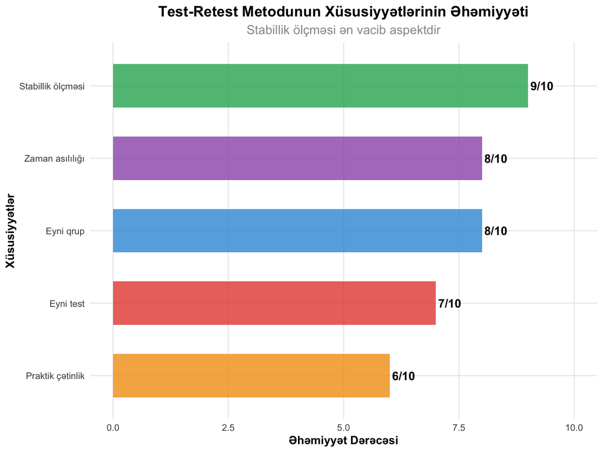

```r
# Xüsusiyyətlərin əhəmiyyət dərəcəsi
ggplot(tr_characteristics, aes(x = reorder(Xususiyyet, Ehemiyyet), y = Ehemiyyet, fill = Xususiyyet)) +
  geom_col(alpha = 0.8, width = 0.6) +
  geom_text(aes(label = paste0(Ehemiyyet, "/10")),
            hjust = -0.1, fontface = "bold", size = 4) +
  coord_flip() +
  scale_fill_manual(values = colors_basic) +
  labs(title = "Test-Retest Metodunun Xüsusiyyətlərinin Əhəmiyyəti",
       subtitle = "Stabillik ölçməsi ən vacib aspektdir",
       x = "Xüsusiyyətlər", y = "Əhəmiyyət Dərəcəsi") +
  theme_clean() +
  theme(legend.position = "none") +
  ylim(0, 10)
```